# DS 624: Homwork 7 (Linear Regression and Cousins)

Kuhn: 6.2, 6.3

Donny Lofland

Source Code: https://github.com/djlofland/DATA624_PredictiveAnalytics/tree/master/Homework_7

## Problem 6.2

Developing a model to predict permeability (see Sect. 1.4) could save significant resources for a pharmaceutical company, while at the same time more rapidly identifying molecules that have a sufficient permeability to become a drug:

1. Start R and use these commands to load the data:

```
library(AppliedPredictiveModeling)
data(permeability)
```

The matrix `fingerprints` contains the 1,107 binary molecular predictors for the 165 compounds, while `permeability` contains permeability response.

```r
data("permeability")

fp <- fingerprints
pm <- permeability

print(paste(nrow(fp), ncol(fp)))
```

```
## [1] "165 1107"
```

```r
print(paste(nrow(pm), ncol(pm)))
```

```
## [1] "165 1"
```

> Note: no missing values found
2. The fingerprint predictors indicate the presence or absence of substructures of a molecule and are often sparse meaning that relatively few of the molecules contain each substructure. Filter out the predictors that have low frequencies using the `nearZeroVar` function from the caret package. How many predictors are left for modeling?

```r
nz <- nearZeroVar(fp)
fp <- fingerprints[,-nz]

print(paste(nrow(fp), ncol(fp)))
```

```
## [1] "165 388"
```

> We have 388 predictors left for predicting.
3. Split the data into a training and a test set, pre-process the data, and tune a PLS model. How many latent variables are optimal and what is the corresponding resampled estimate of $R^2$?

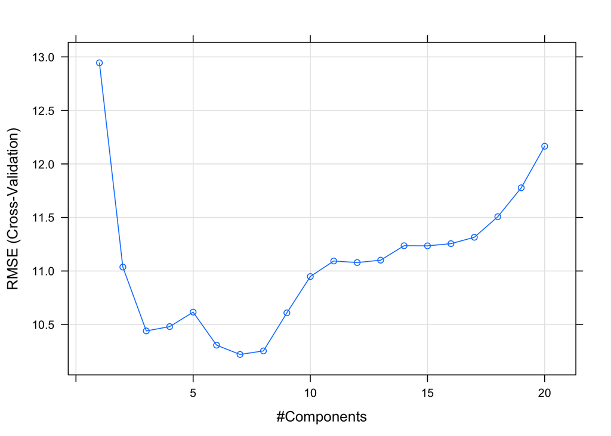

```r
set.seed(424242)

# get training/test split
trainingRows <- createDataPartition(pm, p=0.8, list=FALSE)

# Build training datasets
trainX <- fp[trainingRows,]
trainY <- pm[trainingRows]

# put remaining rows into the test sets
testX <- fp[-trainingRows,]
testY <- pm[-trainingRows]

# Build a DF
trainingData <- as.data.frame(trainX)
trainingData$Perm <- trainY

ctrl <- trainControl(method='cv', number=10)

# run Cv to identify # of latent components
plsTune <- train(trainX, trainY,
                 method="pls",
                 tuneLength=20,
                 trControl = ctrl)
plot(plsTune)
```

```r
# Get the number of components which minimizes RMSE
(optimal_num_comp <- which.min(plsTune$results[,2]))
```

```
## [1] 7
```

```r
(optimal_rmse <- plsTune$results[optimal_num_comp,3])
```

```
## [1] 0.5797039
```

```r
plsFit <- plsr(Perm ~., data=trainingData, ncomp=optimal_num_comp)

plsPred <- predict(plsFit, testX, ncomp=optimal_num_comp)
head(plsPred)
```

```
## , , 7 comps
##
##         Perm
## 2   2.201710
## 3  18.503569
## 4   5.680499
## 8   5.720243
## 19  7.133854
## 22 28.728169
```

```r
plsValues <- data.frame(obs = testY, pred=plsPred)
colnames(plsValues) = c('obs', 'pred')
defaultSummary(plsValues)
```

```
##       RMSE   Rsquared        MAE
## 13.3211161  0.4067846  9.1956516
```

> $R^2$ for the test set is 0.4068
5. Try building other models discussed in this chapter. Do any have better predictive performance?

```r
# Ridge Model
set.seed(100)

ridgeGrid <- data.frame(.lambda=seq(0, 0.2, length=21))

ctrl <- trainControl(method='cv', number=10)

ridgeRegFit <- train(trainX, trainY,
                     method="ridge",
                     tuneGrid = ridgeGrid,
                     trControl = ctrl)
(ridgeRegFit)
```

```
## Ridge Regression
##
## 133 samples
## 388 predictors
##
## No pre-processing
## Resampling: Cross-Validated (10 fold)
## Summary of sample sizes: 120, 120, 119, 121, 120, 119, ...
## Resampling results across tuning parameters:
##
##   lambda  RMSE      Rsquared   MAE
##   0.00    14.04059  0.3155877   9.731223
##   0.01    15.05256  0.3259500  10.671451
##   0.02    13.20238  0.3886225   9.379421
##   0.03    12.51383  0.4167591   8.895310
##   0.04    12.18571  0.4374073   8.720544
##   0.05    11.83622  0.4527312   8.434725
##   0.06    11.66755  0.4629389   8.320563
##   0.07    11.56659  0.4721971   8.255973
##   0.08    11.46803  0.4796161   8.179014
##   0.09    11.35867  0.4860730   8.089975
##   0.10    11.30413  0.4910185   8.041902
##   0.11    11.26373  0.4952875   8.001179
##   0.12    11.23325  0.4990213   7.978158
##   0.13    11.21365  0.5023382   7.964948
##   0.14    11.22380  0.5053486   7.984859
##   0.15    11.21283  0.5082730   7.986088
##   0.16    11.16735  0.5106052   7.958787
##   0.17    11.17855  0.5123371   7.973737
##   0.18    11.16861  0.5145551   7.979657
##   0.19    11.17309  0.5162831   7.993145
##   0.20    11.19009  0.5177423   8.022084
##
## RMSE was used to select the optimal model using the smallest value.
## The final value used for the model was lambda = 0.16.
```

```r
# Do prediction and get R^2
ridgePred <- predict(ridgeRegFit, newdata=testX)

ridgeValues <- data.frame(obs = testY, pred=ridgePred)
colnames(ridgeValues) = c('obs', 'pred')
defaultSummary(ridgeValues)
```

```
##       RMSE   Rsquared        MAE
## 13.7684863  0.3937314 10.1500314
```

```r
set.seed(100)

# LASSO
enetGrid <- expand.grid(.lambda=c(0, 0.01, 0.1),
                        .fraction=seq(0.05, 1, length = 20))

ctrl <- trainControl(method='cv', number=10)

enetTune <- train(trainX, trainY,
                     method="enet",
                     tuneGrid = enetGrid,
                     trControl = ctrl)
```

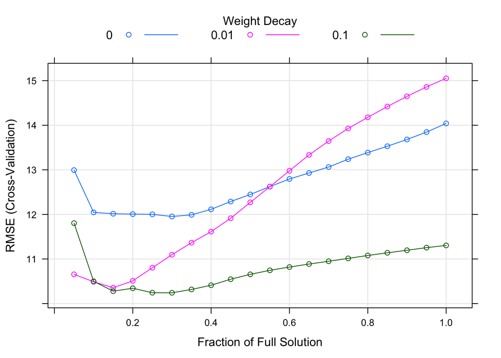

```r
plot(enetTune)
```

```r
summary(enetTune)
```

```
##             Length Class      Mode
## call            4  -none-     call
## actions       192  -none-     list
## allset        388  -none-     numeric
## beta.pure   74496  -none-     numeric
## vn            388  -none-     character
## mu              1  -none-     numeric
## normx         388  -none-     numeric
## meanx         388  -none-     numeric
## lambda          1  -none-     numeric
## L1norm        192  -none-     numeric
## penalty       192  -none-     numeric
## df            192  -none-     numeric
## Cp            192  -none-     numeric
## sigma2          1  -none-     numeric
## xNames        388  -none-     character
## problemType     1  -none-     character
## tuneValue       2  data.frame list
## obsLevels       1  -none-     logical
## param           0  -none-     list
```

```r
lassoPred <- predict(enetTune, newdata=testX)

lassoValues <- data.frame(obs = testY, pred=lassoPred)
colnames(lassoValues) = c('obs', 'pred')
defaultSummary(lassoValues)
```

```
##       RMSE   Rsquared        MAE
## 14.0007919  0.3538517  9.7501498
```

6. Would you recommend any of your models to replace the permeability laboratory experiment?

## Problem 6.3

A chemical manufacturing process for a pharmaceutical product was discussed in Sect. 1.4. In this problem, the objective is to understand the relationship between biological measurements of the raw materials (predictors), measurements of the manufacturing process (predictors), and the response of product yield. Biological predictors cannot be changed but can be used to assess the quality of the raw material before processing. On the other hand, manufacturing process predictors can be changed in the manufacturing process. Improving product yield by 1% will boost revenue by approximately one hundred thousand dollars per batch:

1. Start R and use these commands to load the data:

```
library(AppliedPredictiveModeling)
data(chemicalManufacturing)
```

The matrix `processPredictors` contains the 57 predictors (12 describing the input biological material and 45 describing the process predictors) for the 176 manufacturing runs. `yield` contains the percent yield for each run.

```r
data("ChemicalManufacturingProcess")

cmp <- as_tibble(ChemicalManufacturingProcess)

x_raw <- cmp[,2:58]
y_raw <- as.matrix(cmp$Yield)

print(paste(nrow(x_raw), ncol(x_raw)))
```

```
## [1] "176 57"
```

```r
print(paste(nrow(y_raw), ncol(y_raw)))
```

```
## [1] "176 1"
```

2. A small percentage of cells in the predictor set contain missing values. Use an imputation function to fill in these missing values (e.g., see Sect. 3.8).

```r
# Various NA plots to inspect data
knitr::kable(miss_var_summary(cmp) %>% filter(n_miss > 0),
             caption = 'Missing Values',
             format="html",
             table.attr="style='width:50%;'") %>%
  kableExtra::kable_styling()
```

Missing Values

| variable | n_miss | pct_miss |
| --- | --- | --- |
| ManufacturingProcess03 | 15 | 8.5227273 |
| ManufacturingProcess11 | 10 | 5.6818182 |
| ManufacturingProcess10 | 9 | 5.1136364 |
| ManufacturingProcess25 | 5 | 2.8409091 |
| ManufacturingProcess26 | 5 | 2.8409091 |
| ManufacturingProcess27 | 5 | 2.8409091 |
| ManufacturingProcess28 | 5 | 2.8409091 |
| ManufacturingProcess29 | 5 | 2.8409091 |
| ManufacturingProcess30 | 5 | 2.8409091 |
| ManufacturingProcess31 | 5 | 2.8409091 |
| ManufacturingProcess33 | 5 | 2.8409091 |
| ManufacturingProcess34 | 5 | 2.8409091 |
| ManufacturingProcess35 | 5 | 2.8409091 |
| ManufacturingProcess36 | 5 | 2.8409091 |
| ManufacturingProcess02 | 3 | 1.7045455 |
| ManufacturingProcess06 | 2 | 1.1363636 |
| ManufacturingProcess01 | 1 | 0.5681818 |
| ManufacturingProcess04 | 1 | 0.5681818 |
| ManufacturingProcess05 | 1 | 0.5681818 |
| ManufacturingProcess07 | 1 | 0.5681818 |
| ManufacturingProcess08 | 1 | 0.5681818 |
| ManufacturingProcess12 | 1 | 0.5681818 |
| ManufacturingProcess14 | 1 | 0.5681818 |
| ManufacturingProcess22 | 1 | 0.5681818 |
| ManufacturingProcess23 | 1 | 0.5681818 |
| ManufacturingProcess24 | 1 | 0.5681818 |
| ManufacturingProcess40 | 1 | 0.5681818 |
| ManufacturingProcess41 | 1 | 0.5681818 |

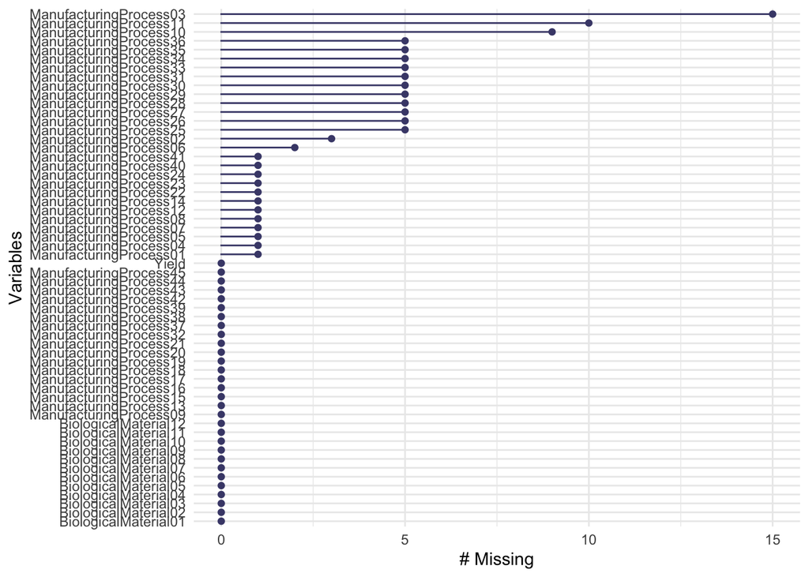

```r
gg_miss_var(cmp)
```

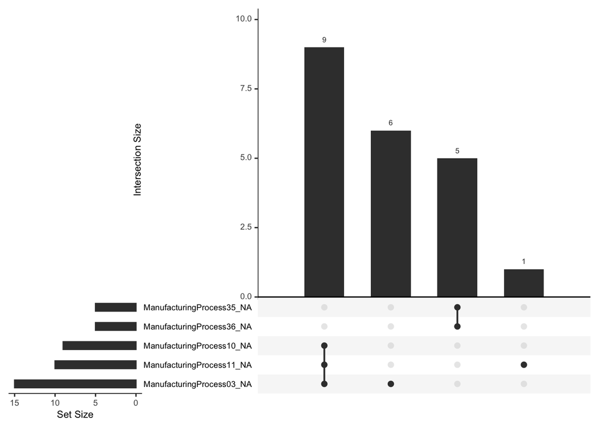

```r
gg_miss_upset(cmp)
```

> Because we see some patterns in how features are missing, I’ll use a KNN Impute approach. Note that the`caret` `knnImpute` also normalizes the data by default. This is annoying - I’m going use `knn.impute` from `bnstruct` instead.

```r
x_imputed <- knn.impute(as.matrix(x_raw), k=10)
```

3. Split the data into a training and a test set, pre-process the data, and tune a model of your choice from this chapter. What is the optimal value of the performance metric?

Let’s check for and drop any features with near zero variance

```r
# Check for columns with little variance - candidate to drop
lowVariance <- nearZeroVar(x_imputed, names = TRUE)
head(lowVariance)
```

```
## [1] "BiologicalMaterial07"
```

```r
lowVariance <- nearZeroVar(x_imputed)
```

```r
# Drop columns with low variance
x_lowvar <- x_imputed[,-lowVariance]
```

Now, lets drop any columns with high correlations

```r
# Find and drop high correlation features
correlations <- cor(x_lowvar)
highCorr <- findCorrelation(correlations, names=TRUE, cutoff=0.9)
(highCorr)
```

```
##  [1] "BiologicalMaterial02"   "BiologicalMaterial04"   "BiologicalMaterial12"
##  [4] "ManufacturingProcess29" "ManufacturingProcess42" "ManufacturingProcess27"
##  [7] "ManufacturingProcess25" "ManufacturingProcess31" "ManufacturingProcess18"
## [10] "ManufacturingProcess40"
```

```r
highCorr <- findCorrelation(correlations, cutoff=0.9)
x_corr <- x_lowvar[,-highCorr]

head(x_corr)
```

```
##      BiologicalMaterial01 BiologicalMaterial03 BiologicalMaterial05
## [1,]                 6.25                56.97                19.51
## [2,]                 8.01                67.48                19.36
## [3,]                 8.01                67.48                19.36
## [4,]                 8.01                67.48                19.36
## [5,]                 7.47                72.25                17.91
## [6,]                 6.12                65.31                21.79
##      BiologicalMaterial06 BiologicalMaterial08 BiologicalMaterial09
## [1,]                43.73                16.66                11.44
## [2,]                53.14                19.04                12.55
## [3,]                53.14                19.04                12.55
## [4,]                53.14                19.04                12.55
## [5,]                54.66                18.22                12.80
## [6,]                51.23                18.30                12.13
##      BiologicalMaterial10 BiologicalMaterial11 ManufacturingProcess01
```

[output cut: 97 more lines]

Now, let’s transform our features (scale, center and boxcox) to improve modeling resolution

```r
x_transf <-  preProcess(x_corr, method=c('center', 'scale', 'BoxCox'))
(x_transf)
```

```
## Created from 176 samples and 46 variables
##
## Pre-processing:
##   - Box-Cox transformation (25)
##   - centered (46)
##   - ignored (0)
##   - scaled (46)
##
## Lambda estimates for Box-Cox transformation:
##    Min. 1st Qu.  Median    Mean 3rd Qu.    Max.
##   -2.00   -2.00   -0.20   -0.08    2.00    2.00
```

```r
x_transf <- predict(x_transf, x_corr)
```

Time to split in to Training and Test

```r
# get training/test split
trainingRows <- createDataPartition(y_raw, p=0.8, list=FALSE)

# Build training datasets
trainX <- x_transf[trainingRows,]
trainY <- y_raw[trainingRows]

# put remaining rows into the test sets
testX <- x_transf[-trainingRows,]
testY <- y_raw[-trainingRows]

# Build a DF
trainingData <- as.data.frame(trainX)
trainingData$Yield <- trainY
```

Build a model:

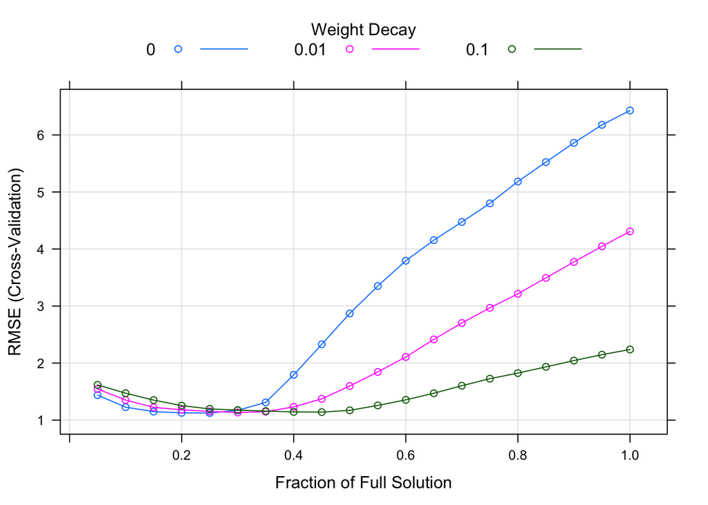

```r
set.seed(100)

# LASSO
enetGrid <- expand.grid(.lambda=c(0, 0.01, 0.1),
                        .fraction=seq(0.05, 1, length = 20))

ctrl <- trainControl(method='cv', number=10)

enetTune <- train(trainX, trainY,
                     method="enet",
                     tuneGrid = enetGrid,
                     trControl = ctrl)
plot(enetTune)
```

```r
summary(enetTune)
```

```
##             Length Class      Mode
## call           4   -none-     call
## actions       63   -none-     list
## allset        46   -none-     numeric
## beta.pure   2898   -none-     numeric
## vn            46   -none-     character
## mu             1   -none-     numeric
## normx         46   -none-     numeric
## meanx         46   -none-     numeric
## lambda         1   -none-     numeric
## L1norm        63   -none-     numeric
## penalty       63   -none-     numeric
## df            63   -none-     numeric
## Cp            63   -none-     numeric
## sigma2         1   -none-     numeric
## xNames        46   -none-     character
## problemType    1   -none-     character
## tuneValue      2   data.frame list
## obsLevels      1   -none-     logical
## param          0   -none-     list
```

```r
lassoPred <- predict(enetTune, newdata=trainX)

lassoValues <- data.frame(obs = trainY, pred=lassoPred)
colnames(lassoValues) = c('obs', 'pred')
defaultSummary(lassoValues)
```

```
##      RMSE  Rsquared       MAE
## 1.0233345 0.6885015 0.8237455
```

4. Predict the response for the test set. What is the value of the performance metric and how does this compare with the resampled performance metric on the training set?

```r
lassoPred <- predict(enetTune, newdata=testX)

lassoValues <- data.frame(obs = testY, pred=lassoPred)
colnames(lassoValues) = c('obs', 'pred')
defaultSummary(lassoValues)
```

```
##      RMSE  Rsquared       MAE
## 1.1723272 0.6607599 0.9488075
```

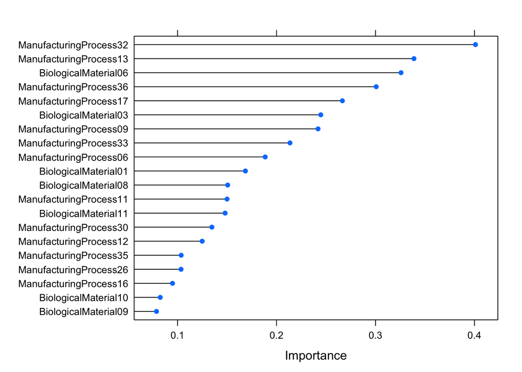

```r
enetImp <- varImp(enetTune, scale = FALSE)
plot(enetImp, top = 20)
```

> We have more Manufacturing Features in the top 20 (13) vs Biological (7). That said, we had more Manufacturing features to start with so, this could just be a class imbalance issue.
6. Explore the relationships between each of the top predictors and the response. How could this information be helpful in improving yield in future runs of the manufacturing process?

```r
# Get top feature names
features <- as.data.frame(enetImp[["importance"]]) %>%
  arrange(-Overall, ) %>%
  rownames()

features <- features[1:20]

cmp_imp <- cmp[features]
cmp_imp$Yield <- cmp$Yield
head(cmp_imp)
```

```
## # A tibble: 6 x 21
##   ManufacturingPr… ManufacturingPr… BiologicalMater… ManufacturingPr…
##              <dbl>            <dbl>            <dbl>            <dbl>
## 1              156             35.5             43.7            0.019
## 2              169             34               53.1            0.019
## 3              173             34.8             53.1            0.018
## 4              171             34.8             53.1            0.018
## 5              171             34.6             54.7            0.017
## 6              173             34               51.2            0.018
## # … with 17 more variables: ManufacturingProcess17 <dbl>,
## #   BiologicalMaterial03 <dbl>, ManufacturingProcess09 <dbl>,
## #   ManufacturingProcess33 <dbl>, ManufacturingProcess06 <dbl>,
## #   BiologicalMaterial01 <dbl>, BiologicalMaterial08 <dbl>,
## #   ManufacturingProcess11 <dbl>, BiologicalMaterial11 <dbl>,
## #   ManufacturingProcess30 <dbl>, ManufacturingProcess12 <dbl>,
## #   ManufacturingProcess35 <dbl>, ManufacturingProcess26 <dbl>,
## #   ManufacturingProcess16 <dbl>, BiologicalMaterial10 <dbl>,
## #   BiologicalMaterial09 <dbl>, Yield <dbl>
```

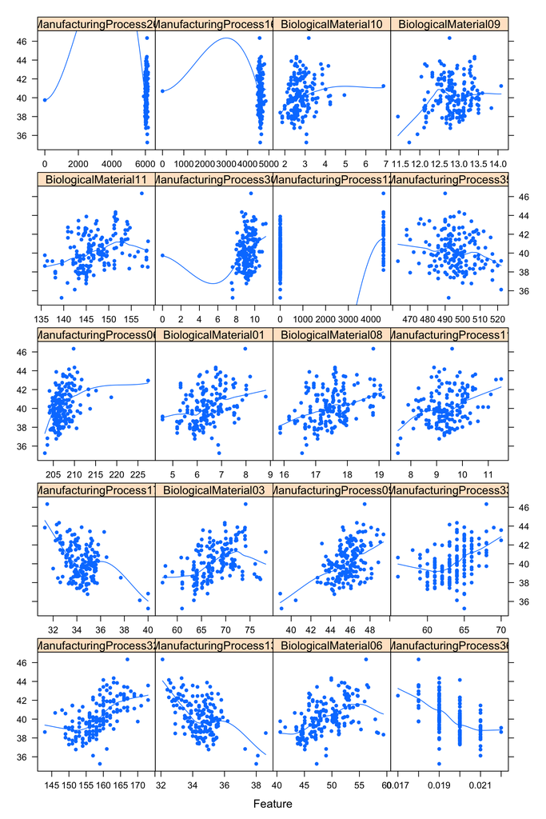

```r
featurePlot(x = cmp_imp[features],
            y = cmp_imp$Yield,
            plot = "scatter",
            type = c("p", 'smooth'),
            span = .5,
            pch = 20)
```

```r
# Show feature correlations/target by decreasing correlation
#stack(sort(cor(clean_df[,1], clean_df[,2:ncol(clean_df)])[,], decreasing=TRUE))
```

> Since we cannot affect Biological Features, we can ignore those for now. However, for the Manufacuring features, we can look for those that show a relationship and try altering our Manufacturing towards the more favorable values. At this point, we haven’t established causation, merely correlation. So, changing those values might not lead to improvements, however these are good candidates for exploration. I would setup experimets where we independently test changing each candidate Manufacturing feature with the strongest correlation and starting from the top of list (based on feature importance) to see if it’s a lever for improving yield. Note: Just because a variable appeared at the top of the feature importance doesn’t mean it is the lever that could have the most impact if changed … but it’s a good place to start and better than just randomly adjusting manufactuing levers.